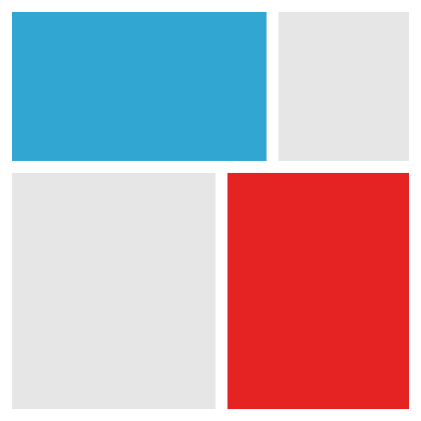

# Petanque

List of distributions

Vahid Nassiri (vahid.nassiri@openanalytics.eu)

# 1 Target location

For now, we need to define `maxTarget` as the maximum location the target could be placed, then the target location itself is generated from a Uniform distribtion as follws:

```r
maxTarget <- 10
targetLocation <- runif(1, min = maxTarget/2, max = maxTarget)
```

# 2 Distribution types

I have considered both continuous and discrete distributions, but except for normal distribution they are all taking positive values. In most of the cases, I let the parameters of the distribution depend on `maxTarget`. Also, the parameters themselves are mostly generated from suitable distributions.

There are some remarks:

Some of the distributions (like log-normal) have long tails, so it is possible that we get very large numbers from them. With other distributions also, obtaining large numebrs is still possible (though not much likely). I think that is still interesting, and we can forsee some expression like “You landed the ball on the moon” or Mars, or Uranus, depending on how large the number is, and then such balls can be considered out of game! But if you find it not that cool, we can change distributions.

We have two irrelevant distributions: Bernouli and beta. Both of them generate random numbers between zero and one, but as Jason suggested, that could be cool as well. And as we will see, even these two still have a chance!

I’ve also include degenerate distribtion. That means our random variable takes only one value with probability one. In fact, that’s not a random variable anymore. That single value itself is generated from a uniform distribution and it will usually be far from the target. I think that would face the user with the question of whether it should take this exact value which is a bit far from the target, or try a random number which could possibly be closer or not.

## 2.1 Binomial

Density: $\binom{N}{k} p ^ k (1-p)^{N-k}$

Expection: $Np$

Variance: $np(1-p)$

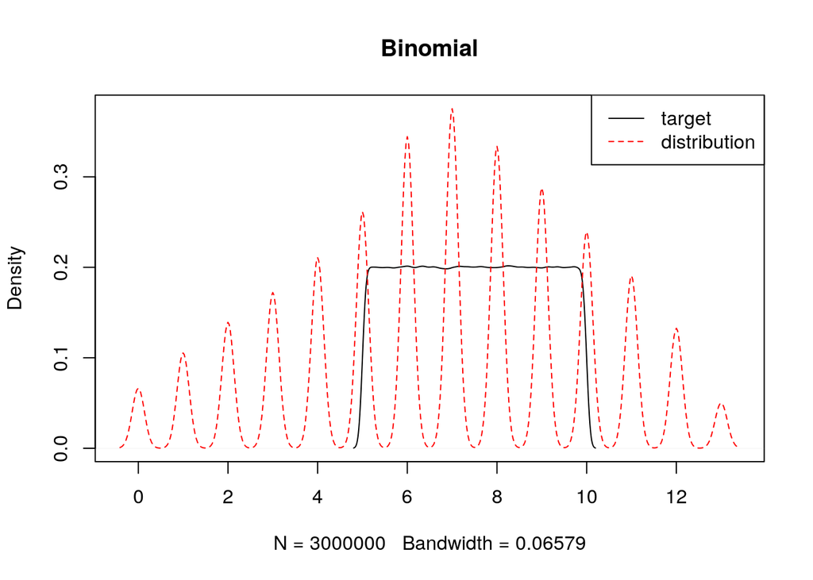

```r
rbinom(1, round(maxTarget * runif(1, 0.5, 1.2))+ 1, rbeta(1, 1.5, 0.6))
```

## 2.2 Poisson

Density: $\frac{\lambda ^k e^{-\lambda}}{k!}$

Expectation: $\lambda$

Variance: $\lambda$

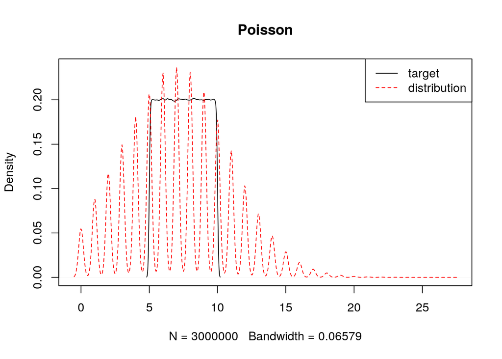

```r
rpois(1, maxTarget * rbeta(1,1.5,0.6))
```

## 2.3 continuous Uniform

Density: $\frac{1}{b-a}$

Expectation: $\frac{a+b}{2}$

Variance: $\frac{(b-a)^2}{12}$

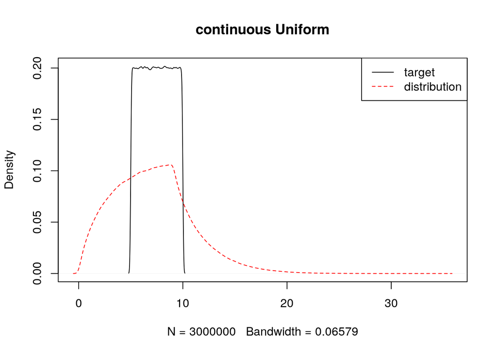

```r
minUnif <- runif(1, 0, maxTarget/2)
maxUnif <- runif(1, minUnif, minUnif + rpois(1, maxTarget * runif(1, 0.55, 2.5)))
runif(1, minUnif, maxUnif)
```

## 2.4 Weibull

Density: $\frac{k}{\lambda}(x/\lambda)^{k-1} \exp\{-(x/\lambda)^k\}, \; x\geq 0$

Expectation: $\lambda \Gamma(1+1/k)$

Variance: $\lambda^2 \left[\Gamma\left(1 + \frac{2}{k} \right) - \left(\Gamma\left(1+\frac{1}{k} \right) \right)^2 \right]$

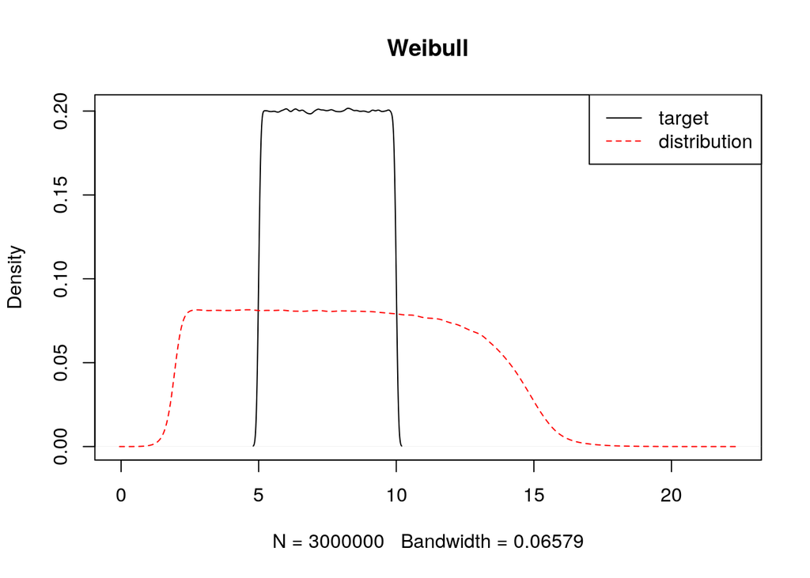

```r
rweibull(1, maxTarget * runif(1,0.5,2.5), maxTarget * runif(1,0.2,1.5))
```

## 2.5 Log-normal

Density: $\frac{1}{x \sigma \sqrt{2\pi}} \exp\left(- \frac{(\ln x - \mu)^2}{2\sigma^2} \right)$

Expectation: $\exp\left(\mu + \frac{\sigma^2}{2} \right)$

Variance: $\left[\exp(\sigma^2) - 1 \right] \exp(2\mu + \sigma^2)$

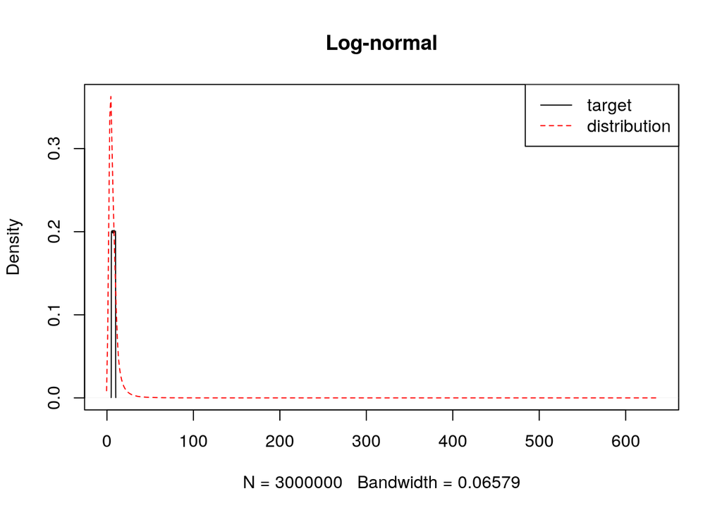

```r
rlnorm(1, runif(1,log(maxTarget*0.3), log(maxTarget*1.1)), runif(1, 0, 1))
```

## 2.6 Chi-squared

Density: $\frac{1}{2^{k/2} \Gamma(k/2}) x^{k/2-1}e^{-x/2}$

Expectation: $k$

Variance: $2k$

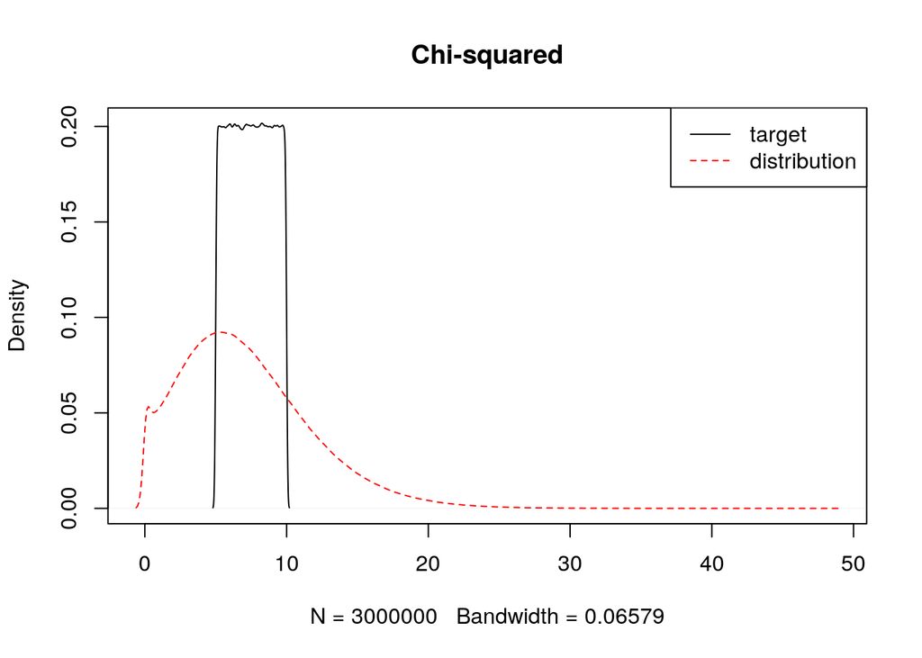

```r
rchisq(1, maxTarget * rbeta(1,1.5,0.6))
```

## 2.7 Normal

Density: $\frac{1}{\sqrt{2\pi\sigma^2}} e^{-\frac{(x-\mu)^2}{2\sigma^2}}$

Expectation: $\mu$

Variance: $\sigma^2$

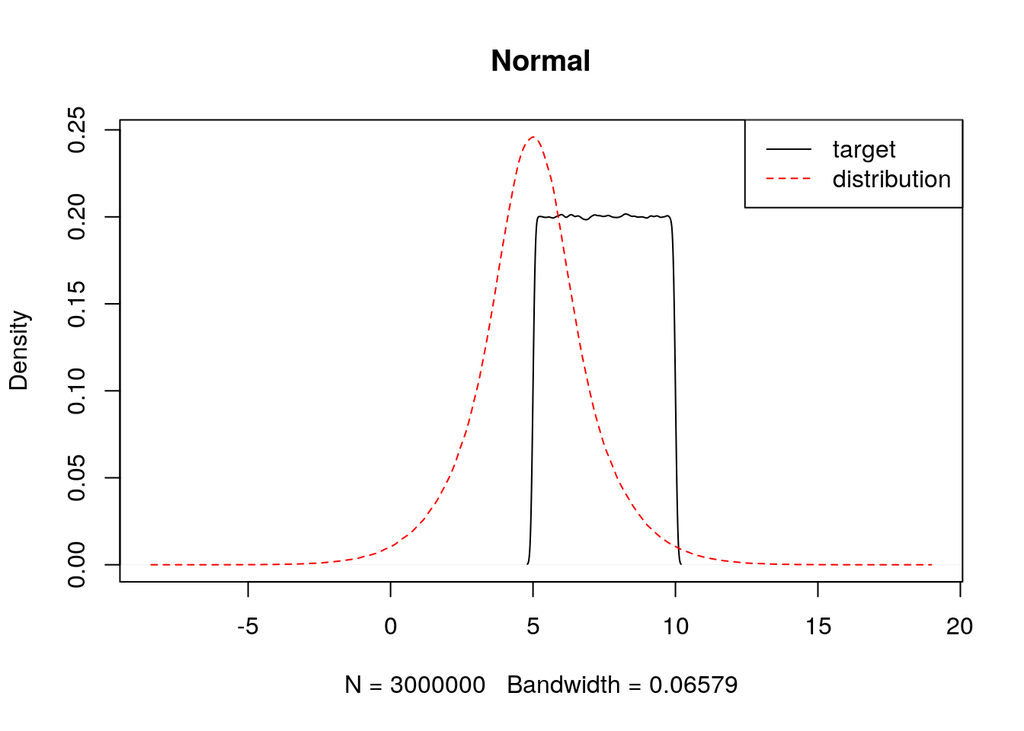

```r
rnorm(1, maxTarget * runif(1, 0.4, 0.6), runif(1, 0.5, 3))
```

## 2.8 Bernoulli

Expectation: $p$

Variance: $p(1-p)$

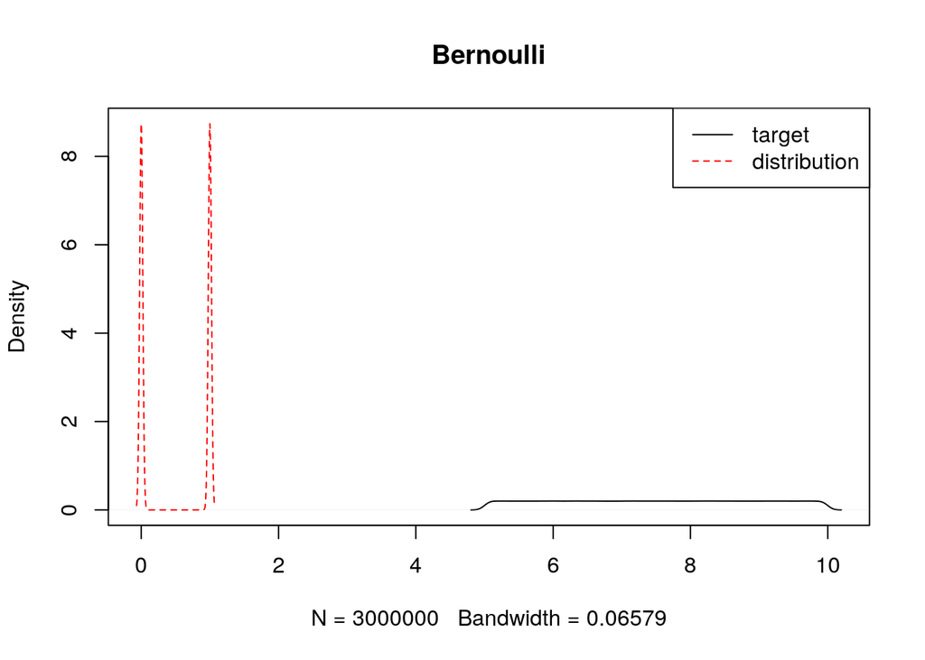

```r
rbinom(1, 1, runif(1, 0.01, 0.99))
```

## 2.9 Beta

Density: $\frac{x^{\alpha-1} (1-x)^{\beta - 1}}{B(\alpha, \beta),\; B(\alpha, \beta) = \frac{\Gamma(\alpha)\Gamma(\beta)}{\Gamma(\alpha + \beta)}}$

Expectation: $\frac{\alpha}{\alpha + \beta}$

Variance: $\frac{\alpha \beta}{(\alpha + \beta)^2 (\alpha + \beta + 1)}$

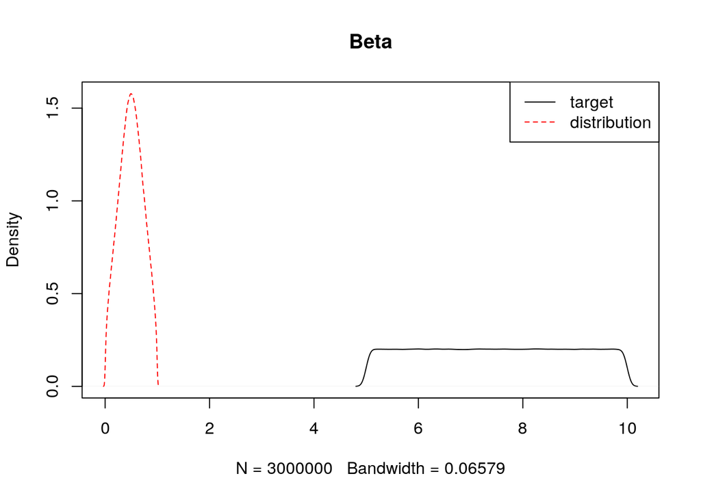

```r
rbeta(1, runif(1,1, 10), runif(1, 1, 10))
```

## 2.10 Degenrate

Density: $Pr(X=k_0) = 1$

Expectation: $k_0$

Variance: $0$

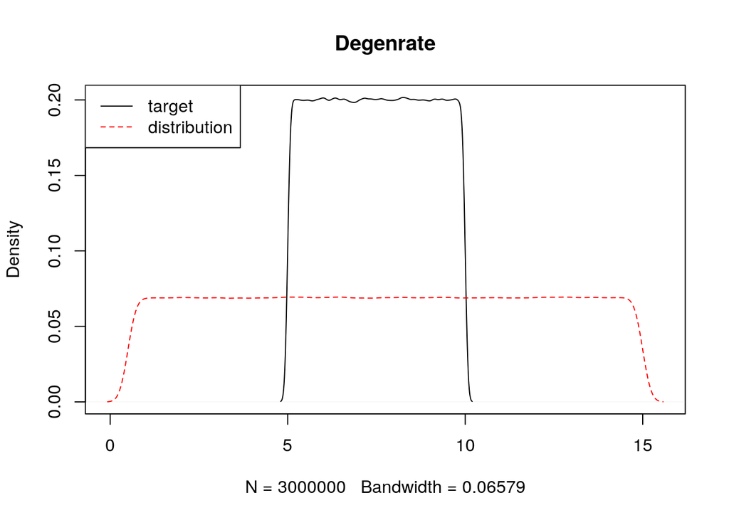

```r
## This is only used to generate k0 above
runif(1, min = maxTarget*0.05, max = maxTarget*1.5)
```

# 3 Some summary

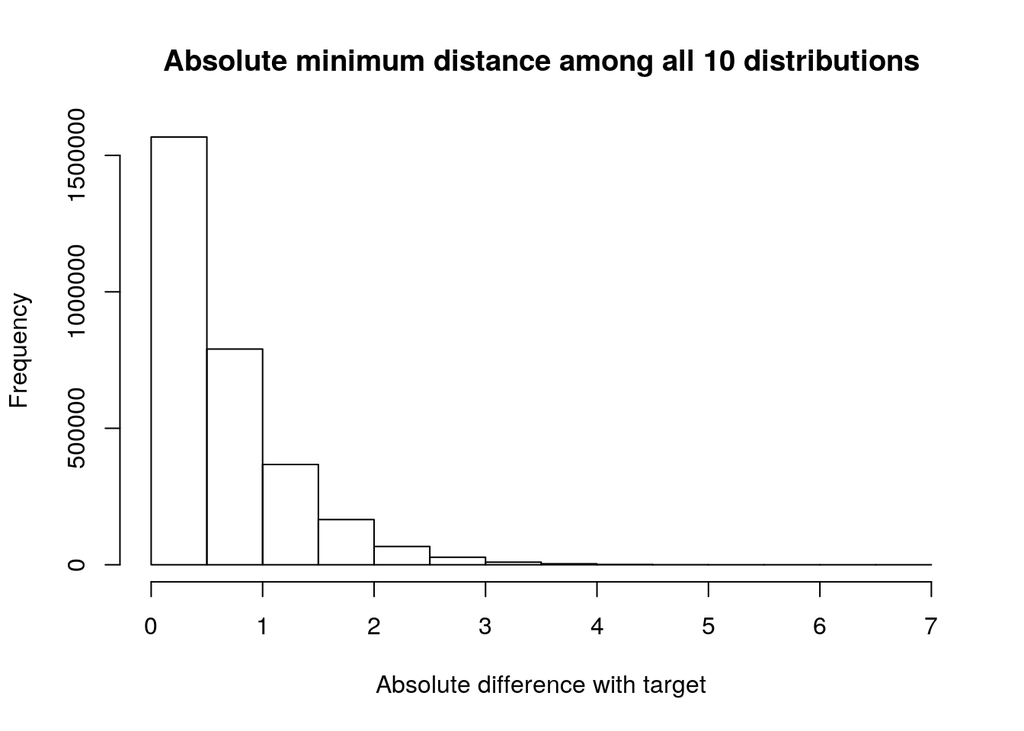

As we may see, with the current sets of parameters, in most of the cases the difference is not larger than 2. In fact, in 0.964 of times we have the minimum difference smalelr than 2, and in 0.786 of times it is smaller than 1.

But we also need the minimum difference to be obtained from different distributions, otherwise the players would know which one is giving the best results after a couple of trials. Here is the frequency table of proportion of times each distribution has generated the closest number to the target.

| binomial | Poisson | uniform | Weibull | log-normal | chi2 | normal | Bernouli | beta | degenerate |
| --- | --- | --- | --- | --- | --- | --- | --- | --- | --- |
| 0.1669397 | 0.126133 | 0.139407 | 0.1154067 | 0.108591 | 0.1104387 | 0.135625 | 7e-07 | 3e-07 | 0.097458 |

Though they are not equally distributed among different distributions, but I guess every one has a reasonable share to make it difficult enough for the user to guess the best one.

It is also interesting to see that in some rare occasions even Bernoulli and beta distributions would give the shortest distance! The following tables will display these cases. That usually happens when the target is small, but all the others are too large or too small, so then a number between 0 and 1 is closer to the target! It should be interesting if this happens to someone! The chance is virtually zero!

| target | binomial | Poisson | uniform | Weibull | log-normal | chi2 | normal | Bernouli | beta | degenerate |
| --- | --- | --- | --- | --- | --- | --- | --- | --- | --- | --- |
| 5.005 | 13 | 12 | 10.530 | 13.290 | 0.695 | 13.372 | 0.688 | 1 | 0.769 | 10.005 |
| 5.123 | 11 | 12 | 17.037 | 11.315 | 18.269 | 11.109 | 0.586 | 1 | 0.800 | 12.227 |

| target | binomial | Poisson | uniform | Weibull | log-normal | chi2 | normal | Bernouli | beta | degenerate |
| --- | --- | --- | --- | --- | --- | --- | --- | --- | --- | --- |
| 5.217 | 10 | 11 | 10.262 | 11.483 | 11.976 | 14.19 | 0.515 | 0 | 0.608 | 12.666 |

# 4 A suggestion for selecting 3 distributions

As we could see, most of the times we have at least one of the distributions that gives a random number with at most 2 units further than the target. Now if we select 3 random distributions we cannot be sure at least one of them is like that, but I guess, what we can do is:

- Generate our random numbers from all 10 distributions
- Compute their absolute differences with target location
- Select the closest one (1st), also two others with medium (4th) and large (8th) distances

|  | best1 | best2 | best3 | best4 | best5 | best6 | best7 | best8 | best9 | best10 |
| --- | --- | --- | --- | --- | --- | --- | --- | --- | --- | --- |
| binomial | 0.167 | 0.153 | 0.142 | 0.129 | 0.116 | 0.103 | 0.087 | 0.063 | 0.023 | 0.017 |
| Poisson | 0.126 | 0.134 | 0.129 | 0.125 | 0.119 | 0.112 | 0.101 | 0.080 | 0.031 | 0.042 |
| uniform | 0.139 | 0.134 | 0.129 | 0.125 | 0.120 | 0.114 | 0.101 | 0.075 | 0.025 | 0.039 |
| Weibull | 0.115 | 0.117 | 0.120 | 0.124 | 0.127 | 0.125 | 0.110 | 0.071 | 0.035 | 0.057 |
| log-normal | 0.109 | 0.113 | 0.119 | 0.125 | 0.129 | 0.127 | 0.112 | 0.076 | 0.016 | 0.075 |
| chi2 | 0.110 | 0.110 | 0.112 | 0.112 | 0.113 | 0.113 | 0.111 | 0.096 | 0.044 | 0.077 |
| normal | 0.136 | 0.140 | 0.146 | 0.149 | 0.144 | 0.124 | 0.091 | 0.050 | 0.008 | 0.011 |
| Bernouli | 0.000 | 0.000 | 0.000 | 0.002 | 0.010 | 0.031 | 0.081 | 0.188 | 0.351 | 0.337 |
| beta | 0.000 | 0.000 | 0.000 | 0.001 | 0.007 | 0.025 | 0.074 | 0.190 | 0.419 | 0.283 |
| degenerate | 0.097 | 0.099 | 0.103 | 0.108 | 0.116 | 0.125 | 0.131 | 0.112 | 0.047 | 0.061 |

As we can see, with this way of selection, still all of the distributions have the chance to be there, also we can be sure in more than 95% of the cases we have at least one distribution with a distance smaller than 2 units.